# BÁO CÁO CHI TIẾT ODICH_SXH_YEAR_2026

Author

Hoang Quoc Cuong

Published

April 23, 2026

# **ODICH_SXH 2026**

Báo cáo được cập nhập vào lúc **2026-04-23 16:50:11 | Dữ liệu ODICH_SXH 2026**

Bản đồ Cần Thơ (thông tin chi tiết phường, xã mới) [**click here**](https://tuhocr.github.io/canthosxh/MAP_CANTHO)

**Để copy file ảnh đồ thị full-size, ta right-click lên hình, chọn `Open image in new tab`**

# 1 **KIỂM TRA DỮ LIỆU**

**Nhập dữ liệu sai lệch năm (vd: file 2025 nhưng lại có bệnh nhân của năm 2026)**

**`Dữ liệu nhập lệch năm`**

```
Dữ liệu ban đầu: 1012
Dữ liệu sau khi lọc theo năm: 1012
Dữ liệu nhập lệch năm: 0
```

**Nếu tổng số `TTYTKV` không vượt quá 22 (năm 2025) hay 20 (năm 2026) thì dữ liệu chính xác.**

**Tổng số TTYTKV là 19**

**`TTYTKV`**

```
    TTYT KV Bình Thủy      TTYT KV Cái Răng  TTYT KV Châu Thành A TTYT KV Châu Thành HG   TTYT KV Cù Lao Dung       TTYT KV Kế Sách
                  375                   136                    16                    23                    11                    32
        TTYT KV Mỹ Tú      TTYT KV Mỹ Xuyên       TTYT KV Ngã Năm         TTYT KV Ô Môn    TTYT KV Phụng Hiệp     TTYT KV Thạnh Trị
                   10                    18                    15                    86                    11                     4
     TTYT KV Thới Lai      TTYT KV Thốt Nốt  TTYT KV TP Sóc Trăng       TTYT KV Trần Đề       TTYT KV Vị Thủy     TTYT KV Vĩnh Châu
                   56                    35                    72                    56                    13                    26
   TTYT KV Vĩnh Thạnh
                   17
Tổng số TTYTKV là 19
```

**Nếu tổng số `PHUONG_XA_MOI` không vượt quá 103 thì dữ liệu chính xác.**

**Tổng số PHUONG_XA_MOI là 83**

**`PHUONG_XA_MOI`**

```
        An Bình     An Lạc Thôn         An Ninh        An Thạnh       Bình Thủy         Cái Khế        Cái Răng      Châu Thành
             46               9              14               8              85              35              55               7
          Cờ Đỏ     Cù Lao Dung         Đại Hải        Đại Ngãi       Đại Thành       Đông Hiệp      Đông Phước      Đông Thuận
              8               3              10               4               2               6               8               4
        Gia Hòa     Hồ Đắc Kiện          Hòa Tú        Hưng Phú         Kế Sách       Khánh Hòa         Lâm Tân Lịch Hội Thượng
              1               9               3              27              10               3               2               2
        Liêu Tú       Long Hưng        Long Phú      Long Tuyền        Mỹ Hương         Mỹ Quới        Mỹ Xuyên         Ngã Bảy
              8               2               9              40               8               4               6               2
        Ngã Năm         Ngọc Tố         Nhơn Ái         Nhơn Mỹ         Nhu Gia       Ninh Kiều           Ô Môn      Phong Điền
              6               5               8               3               9              53              48              23
        Phú Hữu         Phú Lợi         Phú Tâm      Phụng Hiệp      Phước Thới     Phương Bình       Sóc Trăng         Tài Văn
              8              15               5               1              28               1              19               1
         Tân An         Tân Hòa         Tân Lộc        Tân Long       Tân Thạnh        Thạnh An       Thạnh Hòa       Thạnh Phú
             79              10              16               5               5               2               5               4
     Thạnh Quới   Thạnh Thới An      Thạnh Xuân    Thới An Đông       Thới Hưng        Thới Lai       Thới Long        Thốt Nốt
              2               3               3              37               1               8              10              10
      Thuận Hòa      Thuận Hưng         Trần Đề      Trung Hưng      Trung Nhứt    Trường Khánh     Trường Long Trường Long Tây
              4               8              14               3               1              10              23               3
   Trường Thành     Trường Xuân          Vị Tân        Vị Thanh      Vị Thanh 1       Vĩnh Châu        Vĩnh Hải        Vĩnh Lợi
             12              10               2               4               7               4               5               2
     Vĩnh Phước      Vĩnh Thạnh      Vĩnh Trinh
             14               7               6
Tổng số PHUONG_XA_MOI là 83
```

**Nếu kết quả tổng số ca theo `TTYTKV` và `PHUONG_XA_MOI` không vượt quá 103 thì dữ liệu chính xác.**

Số liệu này thể hiện bao nhiều phường xã có ca bệnh tương ứng với trung tâm y tế khu vực, tổng số không vượt qua 103 phường xã. Cần kiểm tra xem 1 phường xã có bị trùng ở các trung tâm y tế khu vực khác nhau không.

**Dữ liệu bị trùng**

```
        An Bình     An Lạc Thôn         An Ninh        An Thạnh       Bình Thủy         Cái Khế        Cái Răng      Châu Thành
              1               1               1               1               1               1               1               1
          Cờ Đỏ     Cù Lao Dung         Đại Hải        Đại Ngãi       Đại Thành       Đông Hiệp      Đông Phước      Đông Thuận
              1               1               1               1               1               1               1               1
        Gia Hòa     Hồ Đắc Kiện          Hòa Tú        Hưng Phú         Kế Sách       Khánh Hòa         Lâm Tân Lịch Hội Thượng
              1               1               1               1               1               1               1               1
        Liêu Tú       Long Hưng        Long Phú      Long Tuyền        Mỹ Hương         Mỹ Quới        Mỹ Xuyên         Ngã Bảy
              1               1               1               1               1               1               1               1
        Ngã Năm         Ngọc Tố         Nhơn Ái         Nhơn Mỹ         Nhu Gia       Ninh Kiều           Ô Môn      Phong Điền
              1               1               1               1               1               1               1               1
        Phú Hữu         Phú Lợi         Phú Tâm      Phụng Hiệp      Phước Thới     Phương Bình       Sóc Trăng         Tài Văn
              1               1               1               1               1               1               1               1
         Tân An         Tân Hòa         Tân Lộc        Tân Long       Tân Thạnh        Thạnh An       Thạnh Hòa       Thạnh Phú
              1               1               1               1               1               1               1               1
     Thạnh Quới   Thạnh Thới An      Thạnh Xuân    Thới An Đông       Thới Hưng        Thới Lai       Thới Long        Thốt Nốt
              1               1               1               1               1               1               1               1
      Thuận Hòa      Thuận Hưng         Trần Đề      Trung Hưng      Trung Nhứt    Trường Khánh     Trường Long Trường Long Tây
              1               1               1               1               1               1               1               1
   Trường Thành     Trường Xuân          Vị Tân        Vị Thanh      Vị Thanh 1       Vĩnh Châu        Vĩnh Hải        Vĩnh Lợi
              1               1               1               1               1               1               1               1
     Vĩnh Phước      Vĩnh Thạnh      Vĩnh Trinh
              1               1               1
Tổng số PHUONG_XA_MOI là 83
[1] TTYTKV        PHUONG_XA_MOI TONG_SO_CA
<0 rows> (or 0-length row.names)
```

# 2 **SỐ** **Ổ DỊCH** **THEO NGÀY [DỮ LIỆU GỐC]**

[**Dữ liệu gốc ODICH_SXH_2026**](https://tuhocr.github.io/canthosxh/REPORT/ODICH_SXH_2026)

# 3 **TỔNG SỐ** **Ổ DỊCH** **TRONG NĂM THEO KHU VỰC**

**Từ ngày 2026-01-01 đến ngày 2026-04-14**

**Tổng số ổ dịch: 1012 | Tổng số TTYT KV: 19 | Tổng số phường, xã: 103**

**Tổng số phường, xã có ổ dịch ODICH_SXH: 83**

**Tổng số phường, xã có KHÔNG có ODICH_SXH: 20 (Hiệp Hưng, Hòa An, Hỏa Lựu, Lai Hòa, Long Bình, Long Mỹ, Long Phú 1, Lương Tâm, Mỹ Phước, Mỹ Tú, Phong Nẫm, Phú Lộc, Tân Bình, Tân Phước Hưng, Thới An Hội, Vị Thủy, Vĩnh Thuận Đông, Vĩnh Tường, Vĩnh Viễn, Xà Phiên)**

| TTYTKV | Phường, xã mới | Tổng số ca |
| --- | --- | --- |
| TTYT KV Bình Thủy | Bình Thủy | 85 |
| TTYT KV Bình Thủy | Tân An | 79 |
| TTYT KV Bình Thủy | Ninh Kiều | 53 |
| TTYT KV Bình Thủy | An Bình | 46 |
| TTYT KV Bình Thủy | Long Tuyền | 40 |
| TTYT KV Bình Thủy | Thới An Đông | 37 |
| TTYT KV Bình Thủy | Cái Khế | 35 |
| TTYT KV Châu Thành A | Tân Hòa | 10 |
| TTYT KV Châu Thành A | Thạnh Xuân | 3 |
| TTYT KV Châu Thành A | Trường Long Tây | 3 |

[output cut: 73 more lines]

# 4 **ĐỒ THỊ TỔNG SỐ** **Ổ DỊCH** **THEO KHU VỰC**

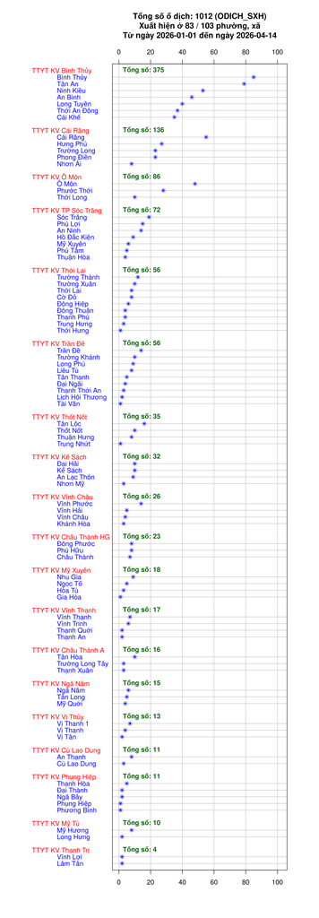

# 5 **TỔNG SỐ** **Ổ DỊCH** **THEO THÁNG**

| TTYTKV | Phường, xã mới | Tháng | Tổng số ca |
| --- | --- | --- | --- |
| TTYT KV Bình Thủy | An Bình | 1 | 10 |
| TTYT KV Kế Sách | An Lạc Thôn | 1 | 3 |
| TTYT KV TP Sóc Trăng | An Ninh | 1 | 4 |
| TTYT KV Cù Lao Dung | An Thạnh | 1 | 1 |
| TTYT KV Bình Thủy | Bình Thủy | 1 | 30 |
| TTYT KV Bình Thủy | Cái Khế | 1 | 8 |
| TTYT KV Cái Răng | Cái Răng | 1 | 28 |
| TTYT KV Châu Thành HG | Châu Thành | 1 | 3 |
| TTYT KV Thới Lai | Cờ Đỏ | 1 | 3 |
| TTYT KV Cù Lao Dung | Cù Lao Dung | 1 | 1 |

[output cut: 228 more lines]

# 6 **ĐỒ THỊ TỔNG SỐ** **Ổ DỊCH** **THEO THỜI GIAN**

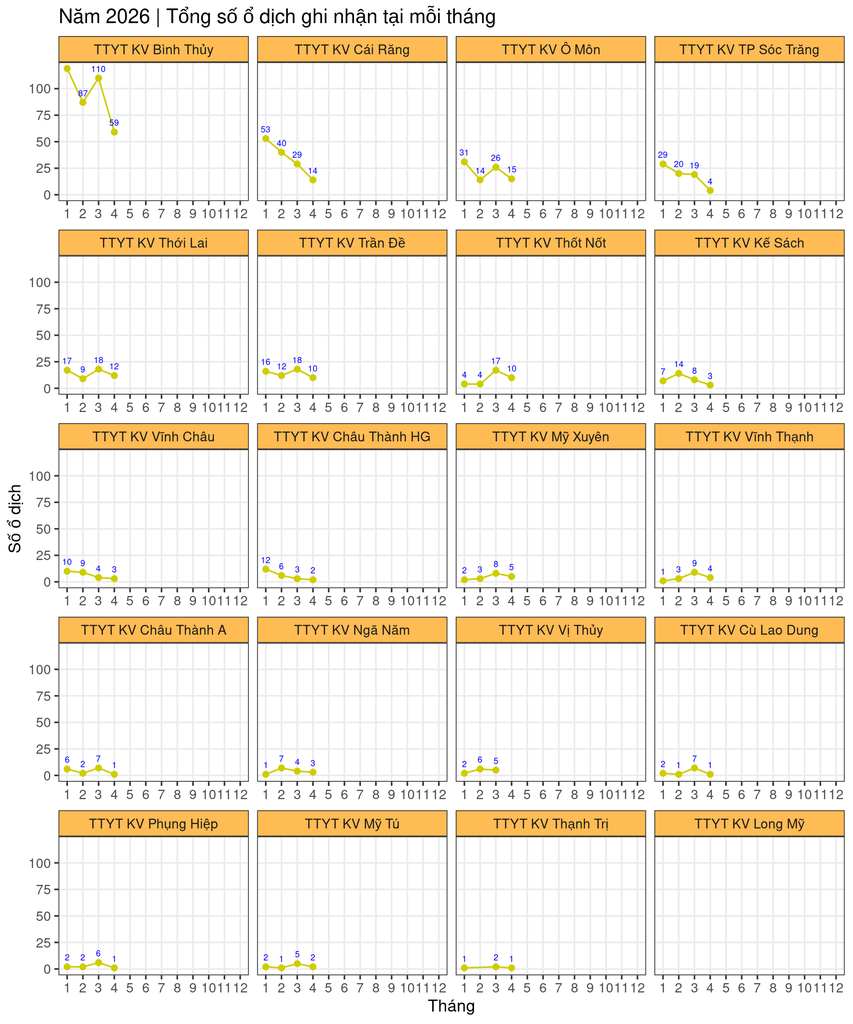

[figure not shown]

# 7 **TỔNG SỐ** **Ổ DỊCH** **THEO TUẦN**

| TTYTKV | PHUONG_XA_MOI | WEEK | COUNT |
| --- | --- | --- | --- |
| TTYT KV Bình Thủy | An Bình | 1 | 3 |
| TTYT KV Kế Sách | An Lạc Thôn | 1 | 2 |
| TTYT KV Bình Thủy | Bình Thủy | 1 | 6 |
| TTYT KV Bình Thủy | Cái Khế | 1 | 1 |
| TTYT KV Cái Răng | Cái Răng | 1 | 6 |
| TTYT KV Châu Thành HG | Châu Thành | 1 | 2 |
| TTYT KV Thới Lai | Đông Hiệp | 1 | 1 |
| TTYT KV TP Sóc Trăng | Hồ Đắc Kiện | 1 | 1 |
| TTYT KV Cái Răng | Hưng Phú | 1 | 2 |
| TTYT KV Vĩnh Châu | Khánh Hòa | 1 | 1 |

[output cut: 481 more lines]

# 8 **ĐỒ THỊ THEO NGÀY**

## 8.1 TTYT KV Cái Răng

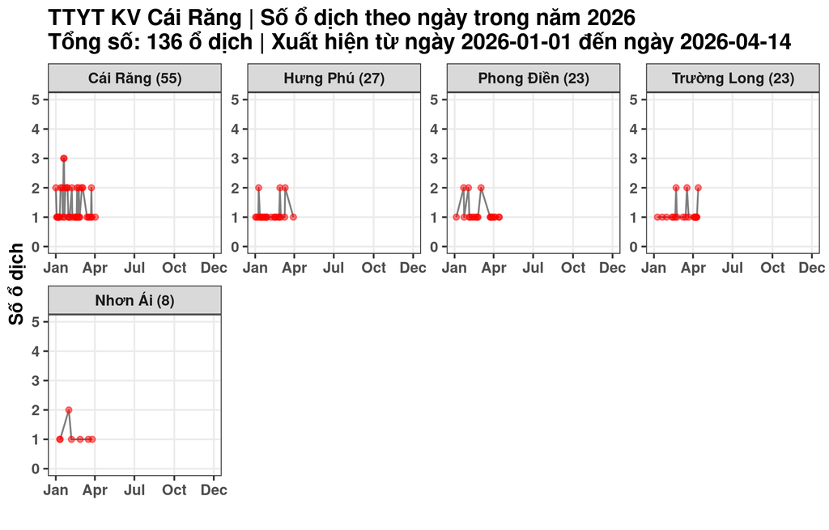

## 8.2 TTYT KV Châu Thành HG

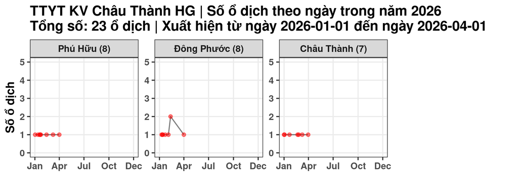

## 8.3 TTYT KV Phụng Hiệp

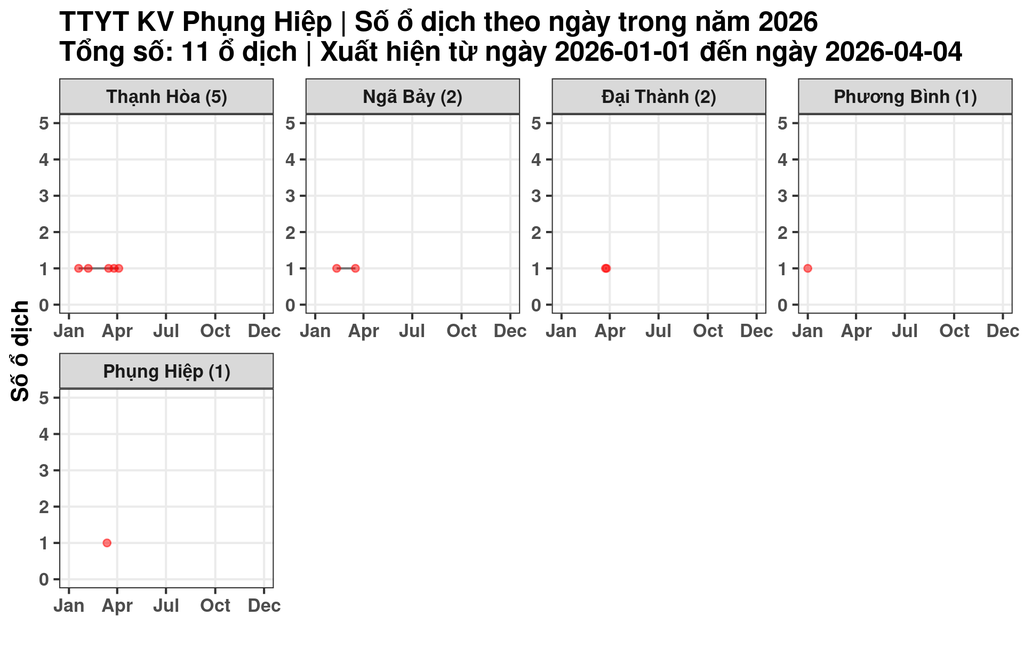

## 8.4 TTYT KV Châu Thành A

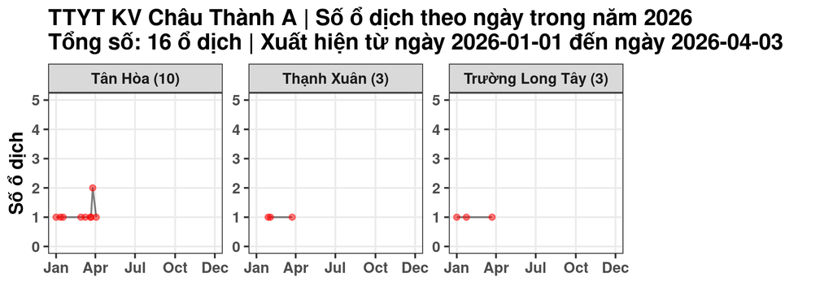

## 8.5 TTYT KV Bình Thủy

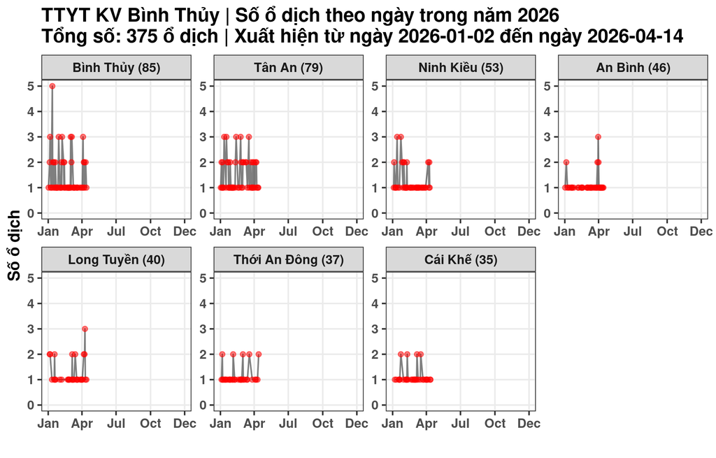

## 8.6 TTYT KV Ô Môn

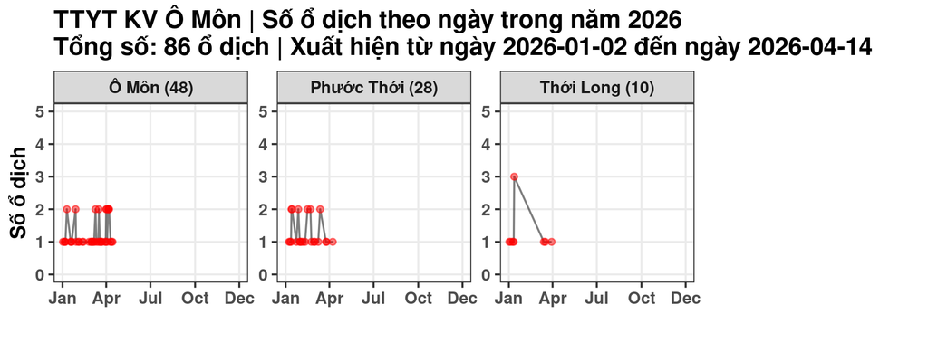

## 8.7 TTYT KV TP Sóc Trăng

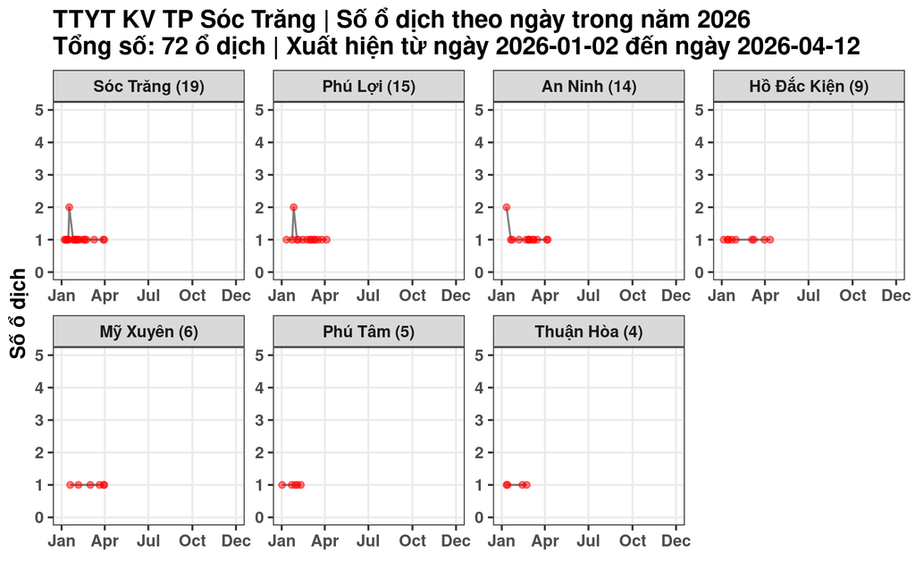

## 8.8 TTYT KV Mỹ Xuyên

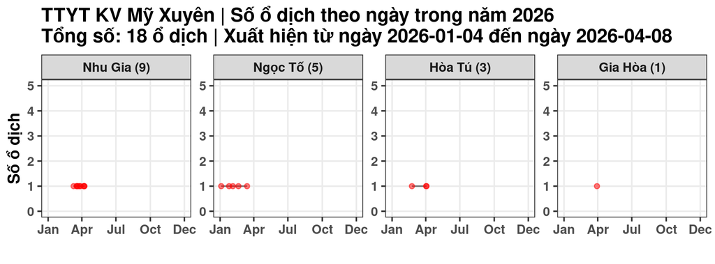

## 8.9 TTYT KV Trần Đề

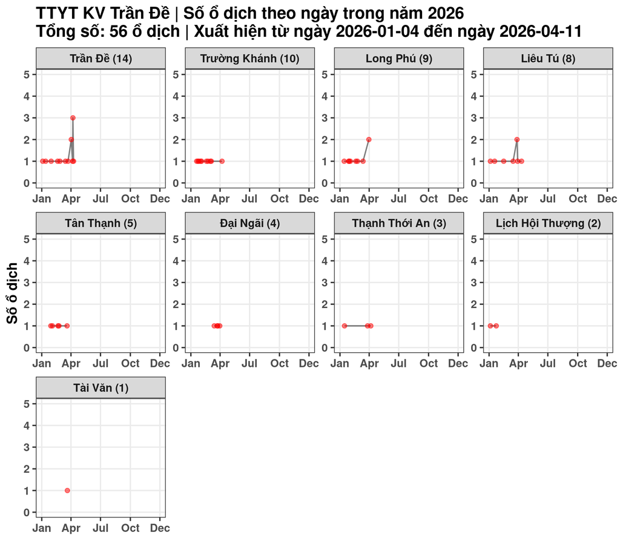

## 8.10 TTYT KV Vĩnh Thạnh

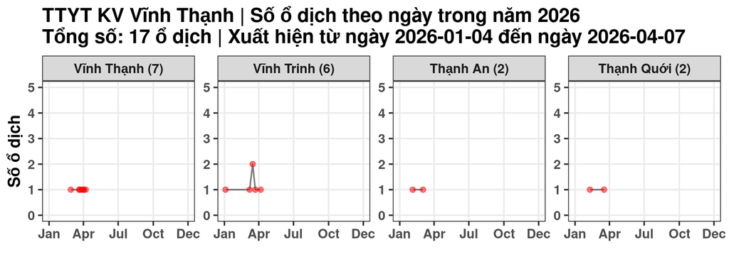

## 8.11 TTYT KV Kế Sách

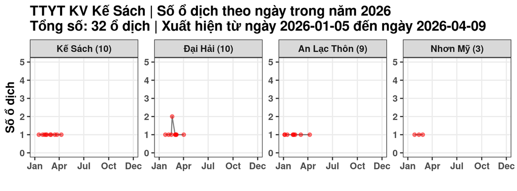

## 8.12 TTYT KV Vĩnh Châu

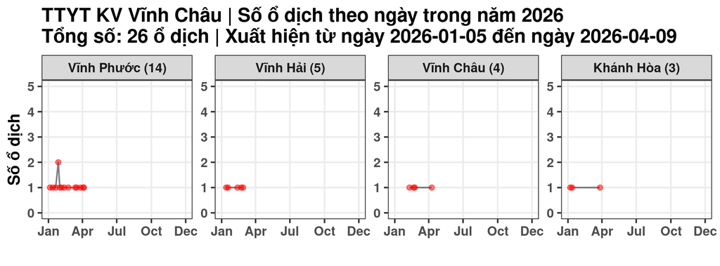

## 8.13 TTYT KV Thạnh Trị

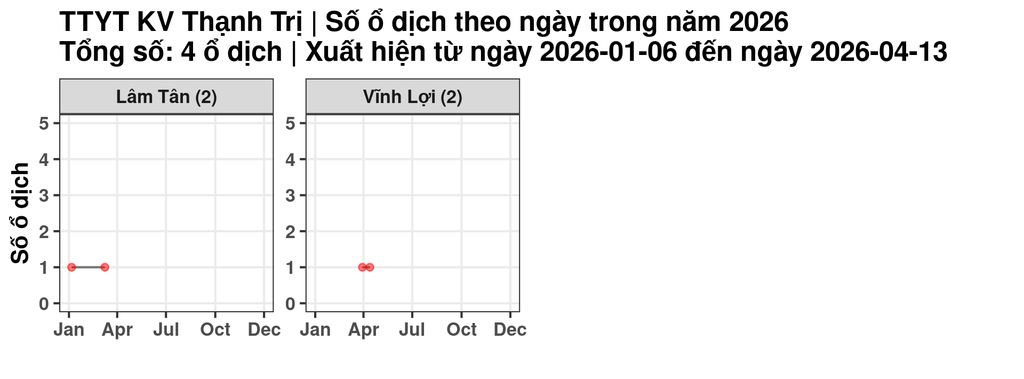

## 8.14 TTYT KV Thới Lai

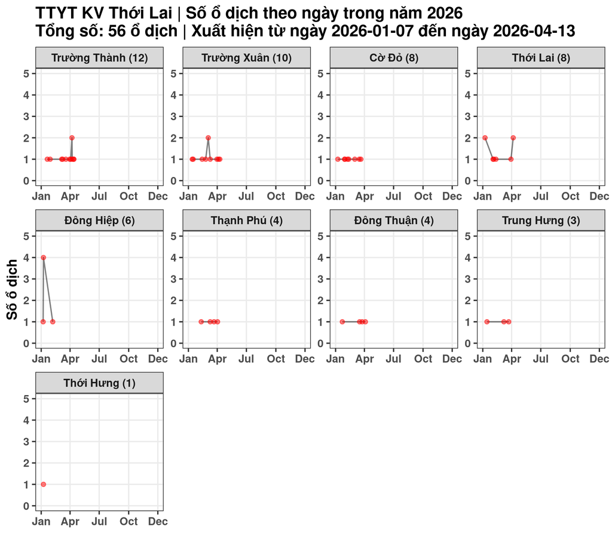

## 8.15 TTYT KV Thốt Nốt

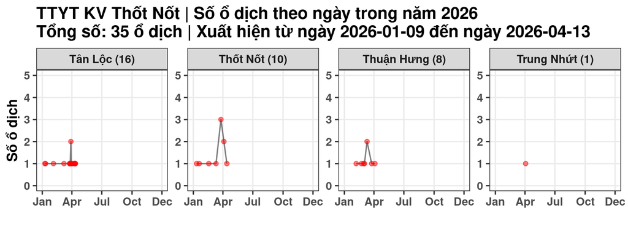

## 8.16 TTYT KV Mỹ Tú

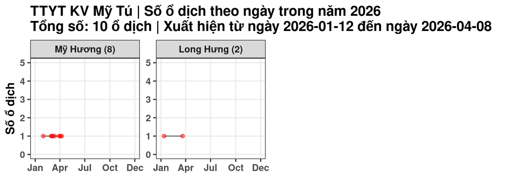

## 8.17 TTYT KV Cù Lao Dung

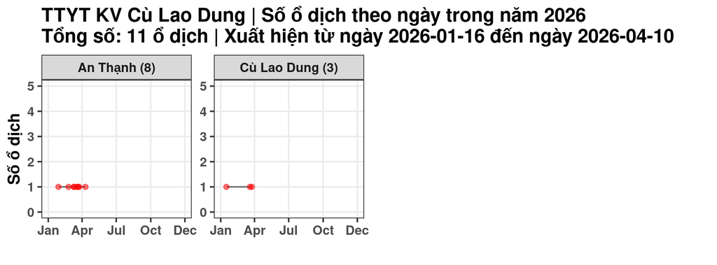

## 8.18 TTYT KV Vị Thủy

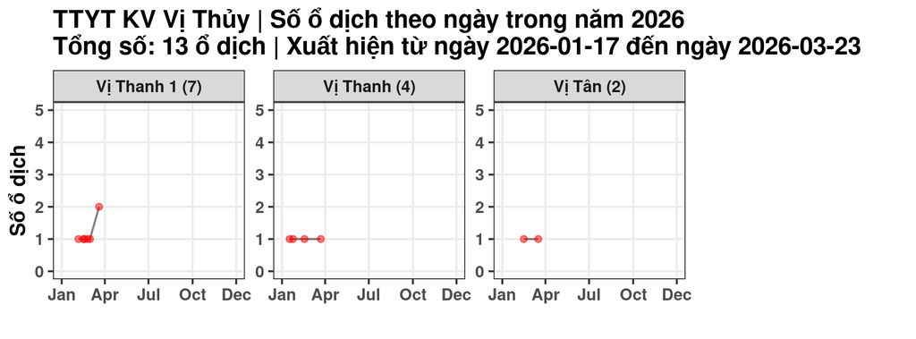

## 8.19 TTYT KV Ngã Năm

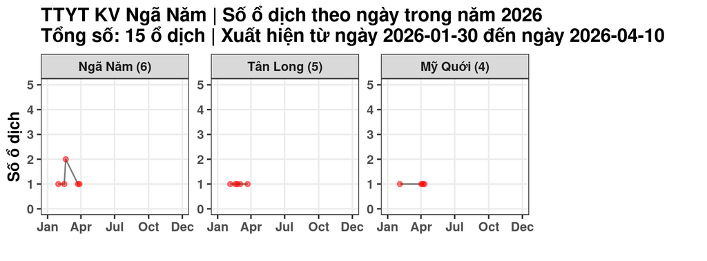

# 9 **ĐỒ THỊ THEO TUẦN**

## 9.1 TTYT KV Bình Thủy

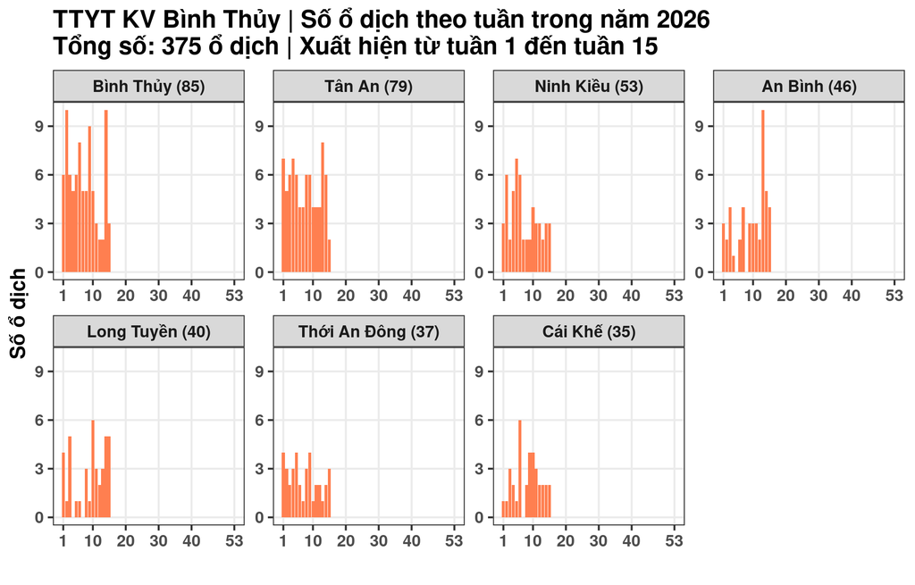

## 9.2 TTYT KV Kế Sách

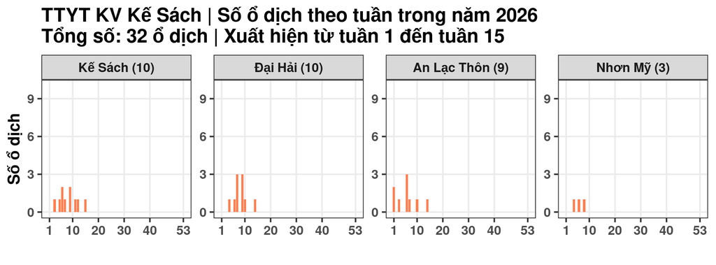

## 9.3 TTYT KV Cái Răng

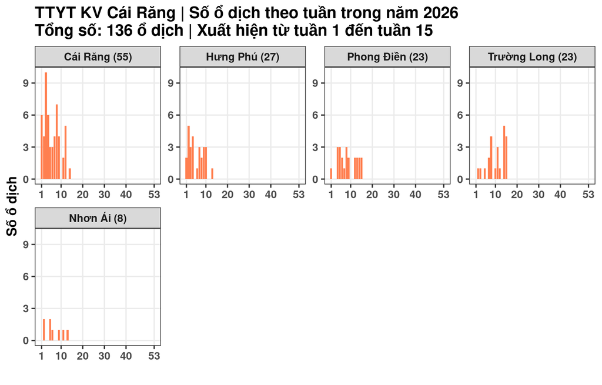

## 9.4 TTYT KV Châu Thành HG

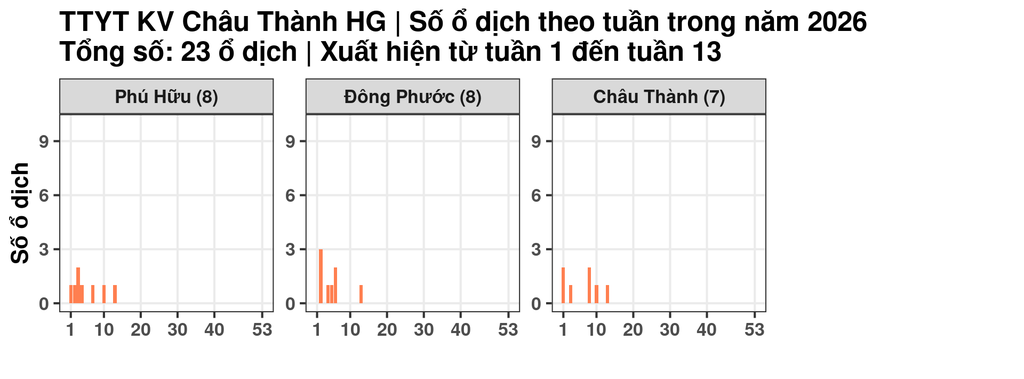

## 9.5 TTYT KV Thới Lai

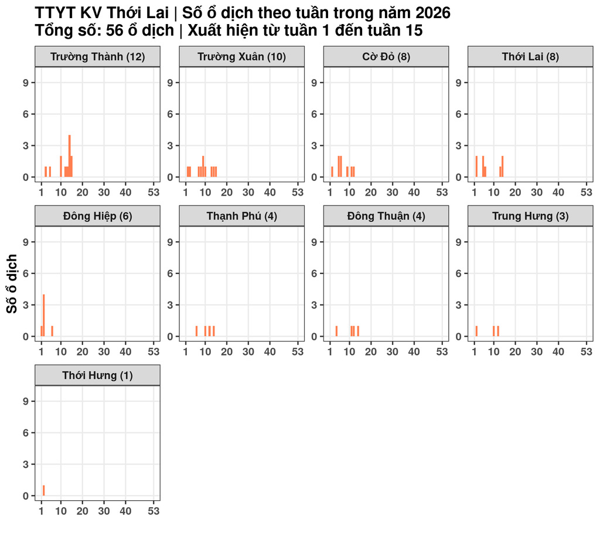

## 9.6 TTYT KV TP Sóc Trăng

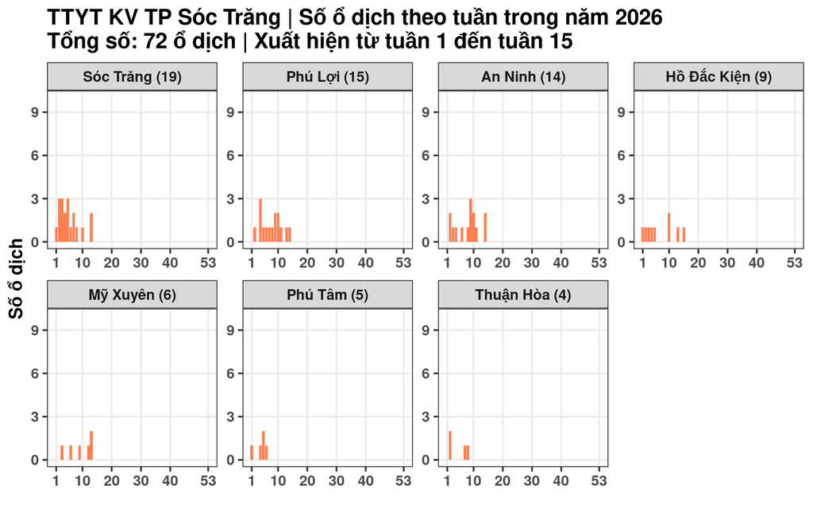

## 9.7 TTYT KV Vĩnh Châu

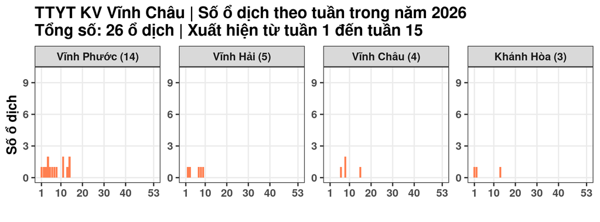

## 9.8 TTYT KV Thạnh Trị

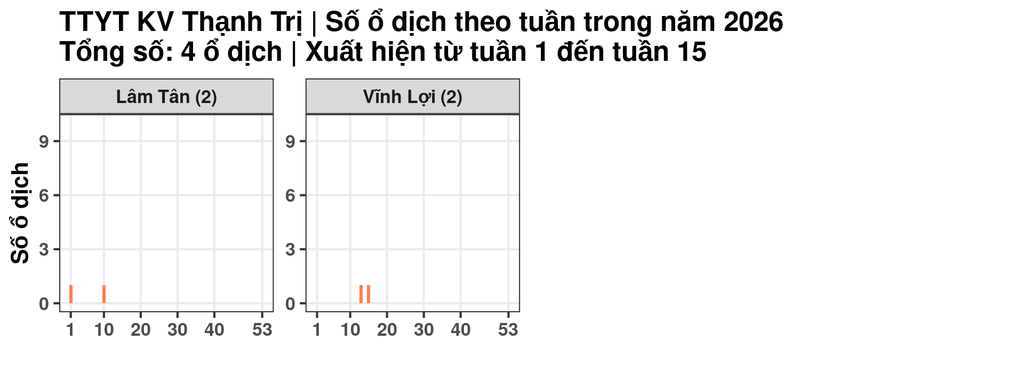